# Kaggle IF 1

# Load the data

```r
data <- read.csv("train.csv")
test_set <- read.csv("test.csv")
head(data)
```

```
##   Age Sex ChestPainType RestingBP Cholesterol FastingBS RestingECG MaxHR
## 1  42   M           NAP       120         240         1     Normal   194
## 2  36   M           NAP       130         209         0     Normal   178
## 3  56   M           ASY       150         213         1     Normal   125
## 4  37   F           NAP       130         211         0     Normal   142
## 5  51   M           ASY       120           0         1     Normal   104
## 6  55   M           ASY       145         248         0     Normal    96
##   ExerciseAngina Oldpeak ST_Slope HeartDisease
## 1              N     0.8     Down            0
## 2              N     0.0       Up            0
## 3              Y     1.0     Flat            1
## 4              N     0.0       Up            0
## 5              N     0.0     Flat            1
## 6              Y     2.0     Flat            1
```

```r
str(data)
```

```
## 'data.frame':    734 obs. of  12 variables:
##  $ Age           : int  42 36 56 37 51 55 52 48 56 35 ...
##  $ Sex           : chr  "M" "M" "M" "F" ...
##  $ ChestPainType : chr  "NAP" "NAP" "ASY" "NAP" ...
##  $ RestingBP     : int  120 130 150 130 120 145 165 160 130 120 ...
##  $ Cholesterol   : int  240 209 213 211 0 248 0 268 256 160 ...
##  $ FastingBS     : int  1 0 1 0 1 0 1 0 1 0 ...
##  $ RestingECG    : chr  "Normal" "Normal" "Normal" "Normal" ...
##  $ MaxHR         : int  194 178 125 142 104 96 122 103 142 185 ...
##  $ ExerciseAngina: chr  "N" "N" "Y" "N" ...
##  $ Oldpeak       : num  0.8 0 1 0 0 2 1 1 0.6 0 ...
##  $ ST_Slope      : chr  "Down" "Up" "Flat" "Up" ...
##  $ HeartDisease  : int  0 0 1 0 1 1 1 1 1 0 ...
```

# Char -> Num

Here we are going to digitize all the **char** to have only quantitative and non-qualitative variables (for our 2 data)

```r
data$Sex <- factor(data$Sex, levels = c("F","M"), labels = c(0,1))
data$ChestPainType <- factor(data$ChestPainType, levels = c("NAP","ASY","TA","ATA"), labels = c(0,1,2,3))
data$RestingECG <- factor(data$RestingECG, levels = c("Normal","ST","LVH"), labels = c(0,1,2))
data$ExerciseAngina <- factor(data$ExerciseAngina, levels = c("N","Y"), labels = c(0,1))
data$ST_Slope <- factor(data$ST_Slope, levels = c("Flat","Up","Down"), labels = c(0,1,2))



data$Sex <- as.numeric(data$Sex)
data$ChestPainType <- as.numeric(data$ChestPainType)
data$RestingECG <- as.numeric(data$RestingECG)
data$ExerciseAngina <- as.numeric(data$ExerciseAngina)
data$ST_Slope <- as.numeric(data$ST_Slope)

#data
str(data)
```

```
## 'data.frame':    734 obs. of  12 variables:
##  $ Age           : int  42 36 56 37 51 55 52 48 56 35 ...
##  $ Sex           : num  2 2 2 1 2 2 2 2 2 1 ...
##  $ ChestPainType : num  1 1 2 1 2 2 2 2 1 3 ...
##  $ RestingBP     : int  120 130 150 130 120 145 165 160 130 120 ...
##  $ Cholesterol   : int  240 209 213 211 0 248 0 268 256 160 ...
##  $ FastingBS     : int  1 0 1 0 1 0 1 0 1 0 ...
##  $ RestingECG    : num  1 1 1 1 1 1 1 1 3 2 ...
##  $ MaxHR         : int  194 178 125 142 104 96 122 103 142 185 ...
##  $ ExerciseAngina: num  1 1 2 1 1 2 2 2 2 1 ...
##  $ Oldpeak       : num  0.8 0 1 0 0 2 1 1 0.6 0 ...
##  $ ST_Slope      : num  3 2 1 2 1 1 2 1 1 2 ...
##  $ HeartDisease  : int  0 0 1 0 1 1 1 1 1 0 ...
```

```r
test_set$Sex <- factor(test_set$Sex, levels = c("F","M"), labels = c(0,1))
test_set$ChestPainType <- factor(test_set$ChestPainType, levels = c("NAP","ASY","TA","ATA"), labels = c(0,1,2,3))
test_set$RestingECG <- factor(test_set$RestingECG, levels = c("Normal","ST","LVH"), labels = c(0,1,2))
test_set$ExerciseAngina <- factor(test_set$ExerciseAngina, levels = c("N","Y"), labels = c(0,1))
test_set$ST_Slope <- factor(test_set$ST_Slope, levels = c("Flat","Up","Down"), labels = c(0,1,2))



test_set$Sex <- as.numeric(test_set$Sex)
test_set$ChestPainType <- as.numeric(test_set$ChestPainType)
test_set$RestingECG <- as.numeric(test_set$RestingECG)
test_set$ExerciseAngina <- as.numeric(test_set$ExerciseAngina)
test_set$ST_Slope <- as.numeric(test_set$ST_Slope)

#test_set
str(test_set)
```

```
## 'data.frame':    184 obs. of  11 variables:
##  $ Age           : int  63 53 65 56 54 67 56 69 46 58 ...
##  $ Sex           : num  1 2 2 2 2 2 2 2 2 2 ...
##  $ ChestPainType : num  4 1 2 2 4 2 2 1 3 2 ...
##  $ RestingBP     : int  140 145 160 130 108 125 120 142 140 120 ...
##  $ Cholesterol   : int  195 518 0 0 309 254 0 271 272 0 ...
##  $ FastingBS     : int  0 0 1 0 0 1 0 0 1 0 ...
##  $ RestingECG    : num  1 1 2 3 1 1 2 3 1 3 ...
##  $ MaxHR         : int  179 130 122 122 156 163 148 126 175 106 ...
##  $ ExerciseAngina: num  1 1 1 2 1 1 1 1 1 2 ...
##  $ Oldpeak       : num  0 0 1.2 1 0 0.2 0 0.3 2 1.5 ...
##  $ ST_Slope      : num  2 1 1 1 2 1 1 2 1 3 ...
```

# split

We come to split our train to **evaluate** our model.

```r
require(caTools)
set.seed(123)


split = sample.split(data$HeartDisease, SplitRatio = 0.8)

training = subset(data, split == TRUE)
testing = subset(data, split == FALSE)

#dim(training)
#dim(testing)
```

# Scale data

We scale our variables so that they are **scaled**.

```r
training[,1:11] = scale(training[,1:11])
testing[,1:11] = scale(testing[,1:11])
test_set[,] = scale(test_set[,])
```

# PCA

```r
library(ggplot2)
library(FactoMineR)
library(factoextra)
res.pca <- PCA(data, scale.unit = TRUE, graph = FALSE)
```

```r
print(res.pca)
```

```
## **Results for the Principal Component Analysis (PCA)**
## The analysis was performed on 734 individuals, described by 12 variables
## *The results are available in the following objects:
##
##    name               description
## 1  "$eig"             "eigenvalues"
## 2  "$var"             "results for the variables"
## 3  "$var$coord"       "coord. for the variables"
## 4  "$var$cor"         "correlations variables - dimensions"
## 5  "$var$cos2"        "cos2 for the variables"
## 6  "$var$contrib"     "contributions of the variables"
## 7  "$ind"             "results for the individuals"
## 8  "$ind$coord"       "coord. for the individuals"
## 9  "$ind$cos2"        "cos2 for the individuals"
## 10 "$ind$contrib"     "contributions of the individuals"
## 11 "$call"            "summary statistics"
## 12 "$call$centre"     "mean of the variables"
## 13 "$call$ecart.type" "standard error of the variables"
## 14 "$call$row.w"      "weights for the individuals"
## 15 "$call$col.w"      "weights for the variables"
```

We look at the eigen values of our pca.

```r
get_eigenvalue(res.pca)
```

```
##        eigenvalue variance.percent cumulative.variance.percent
## Dim.1   3.0897191        25.747660                    25.74766
## Dim.2   1.4580297        12.150248                    37.89791
## Dim.3   1.1638985         9.699154                    47.59706
## Dim.4   0.9851726         8.209771                    55.80683
## Dim.5   0.9274599         7.728833                    63.53567
## Dim.6   0.8347125         6.955938                    70.49160
## Dim.7   0.8046402         6.705335                    77.19694
## Dim.8   0.7655911         6.379926                    83.57686
## Dim.9   0.6057669         5.048058                    88.62492
## Dim.10  0.5730902         4.775752                    93.40067
## Dim.11  0.4368222         3.640185                    97.04086
## Dim.12  0.3550971         2.959142                   100.00000
```

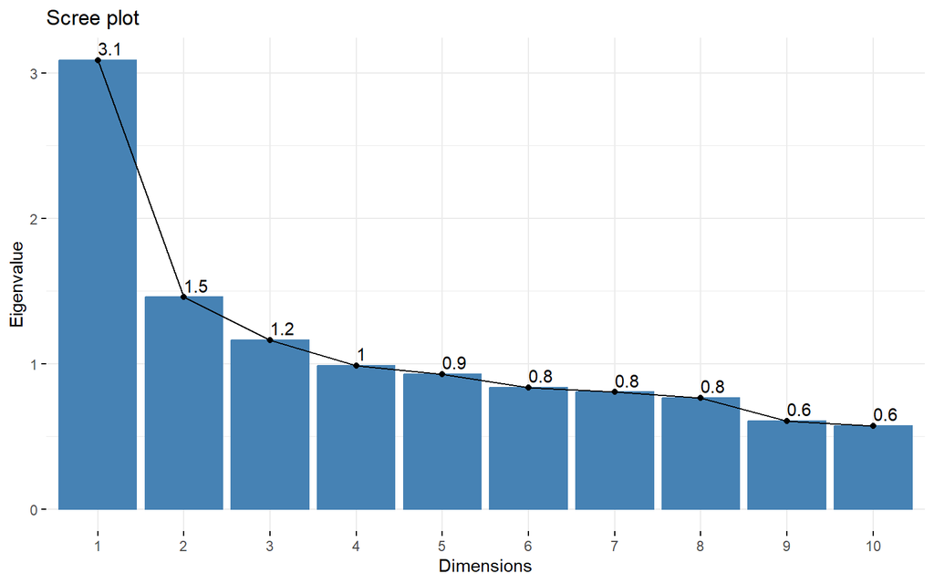

```r
fviz_eig(res.pca, choice = "eigenvalue", addlabels=TRUE)
```

The eigenvalues represent the amount of variance explained by each dimension. Here we observe that we have obtained the screeplot of the eigenvalues. In general, there are two methods to determine the number of axes to take into account. Either we retain the axes where the eigenvalues are greater than 1 (Kaiser criteria) or we take the eigenvalues which dominate the others. Here as we display a screeplot we retain the axes where the eigenvalues dominate the others.

When the values starts to begin to become constant we can admit that the extra dimensions will not bring more interesting information. Here, we keep the axis which is associated with the eigenvalue equal to 3.1 as well as the axis associated with the eigenvalue equal to 1.5.

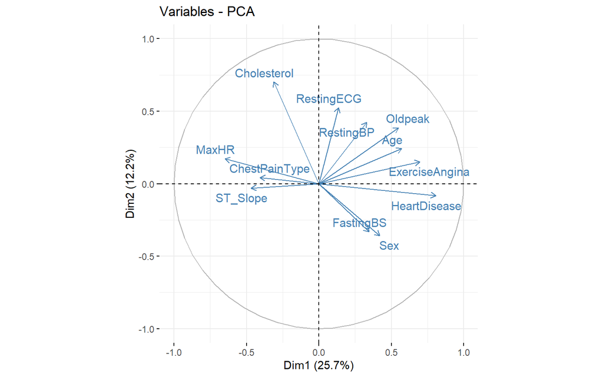

```r
fviz_pca_var(res.pca, repel = TRUE, col.var = "steelblue")
```

The **cosine of the angle** between the arrows representing **2 variables** in the space of origins is equal to the linear **correlation coefficient** between the **2 variables**.

The graph of the circle of correlation makes it possible to interpret the graph of the individuals.

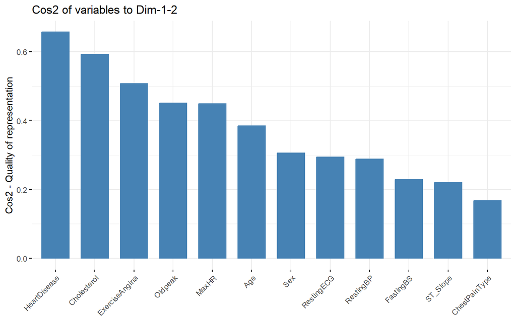

```r
fviz_cos2(res.pca, choice = "var", axes = 1:2)
```

Here we can see that the variables cholesterol, exerciceangina, oldpeak,MaxHR and Age are the variables which are the best represented.So it is consistent with what we tell before.

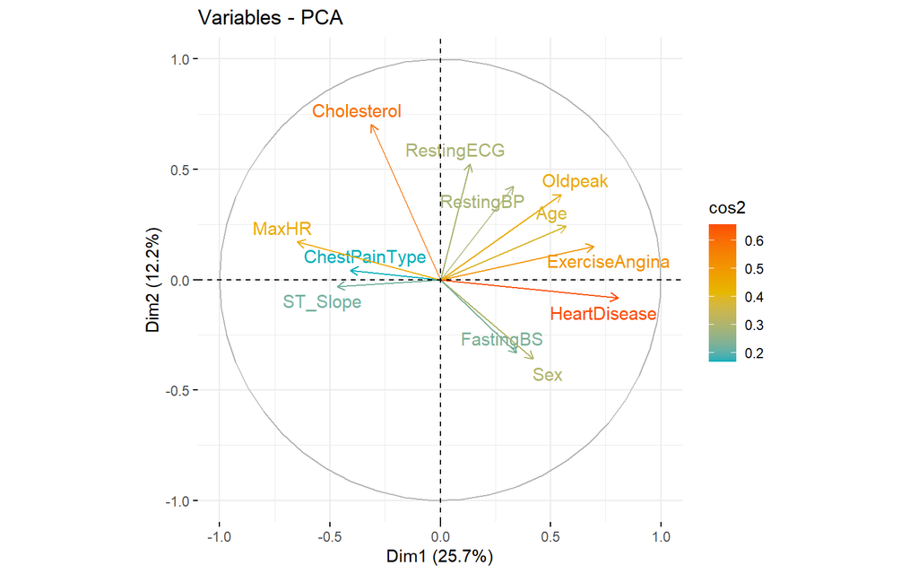

```r
fviz_pca_var(res.pca, col.var = "cos2",
             gradient.cols = c("#00AFBB", "#E7B800", "#FC4E07"),
             repel = TRUE )
```

```r
dimdesc(res.pca)
```

```
## $Dim.1
##
## Link between the variable and the continuous variables (R-square)
## =================================================================================
##                correlation       p.value
## HeartDisease     0.8065294 2.944237e-169
## ExerciseAngina   0.6959903 2.148064e-107
## Age              0.5710392  9.570856e-65
## Oldpeak          0.5486039  6.534896e-59
## Sex              0.4209365  6.961937e-33
## FastingBS        0.3466287  3.790873e-22
## RestingBP        0.3305034  3.625966e-20
## RestingECG       0.1343670  2.615354e-04
## Cholesterol     -0.3125352  4.281722e-18
## ChestPainType   -0.4071107  1.130808e-30
## ST_Slope        -0.4686432  2.395271e-41
## MaxHR           -0.6481553  1.103659e-88
##
## $Dim.2
##
## Link between the variable and the continuous variables (R-square)
## =================================================================================
##                correlation       p.value
## Cholesterol     0.70312954 1.652205e-110
## RestingECG      0.52543202  2.480239e-53
## RestingBP       0.42303036  3.153983e-33
## Oldpeak         0.38738041  1.080302e-27
## Age             0.24211528  2.981896e-11
## MaxHR           0.17188957  2.815026e-06
## ExerciseAngina  0.15173085  3.664524e-05
## HeartDisease   -0.08247512  2.545340e-02
## FastingBS      -0.33032798  3.804775e-20
## Sex            -0.35866260  1.055523e-23
##
## $Dim.3
##
## Link between the variable and the continuous variables (R-square)
## =================================================================================
##                correlation      p.value
## FastingBS       0.59188182 1.390678e-70
## Age             0.46727538 4.376643e-41
## ST_Slope        0.39106701 3.103792e-28
## RestingECG      0.37702281 3.303150e-26
## RestingBP       0.27786973 1.763075e-14
## ChestPainType   0.11932931 1.199531e-03
## Sex            -0.09484544 1.014017e-02
## Oldpeak        -0.14385589 9.186742e-05
## HeartDisease   -0.15398376 2.793271e-05
## Cholesterol    -0.24207897 3.002778e-11
## ExerciseAngina -0.31095159 6.420962e-18
```

# Extract the result for individuals

```r
 ind <- get_pca_ind(res.pca)
 head(ind$coord) # coordinates of individuals
```

```
##       Dim.1      Dim.2      Dim.3      Dim.4       Dim.5
## 1 -2.224161 -1.1080773  1.0261723 -1.4651772  2.16405675
## 2 -2.314033 -0.8475807 -0.8457552 -1.0427401  0.61662263
## 3  2.034134 -0.4765549  0.1903569  0.7237566 -0.27340980
## 4 -2.330599 -0.3078258 -0.5911197 -0.7062806 -0.93377252
## 5  1.117934 -2.9707688  0.6915625 -0.1156133 -1.06082465
## 6  2.131330  0.3813057 -1.4284088  1.0833353 -0.04972855
```

```r
head(ind$contrib, 4)
```

```
##       Dim.1       Dim.2       Dim.3      Dim.4      Dim.5
## 1 0.2181311 0.114730185 0.123262046 0.29687386 0.68793289
## 2 0.2361152 0.067127376 0.083729441 0.15036398 0.05585315
## 3 0.1824502 0.021220881 0.004241563 0.07243972 0.01098087
## 4 0.2395080 0.008854165 0.040901545 0.06898366 0.12808284
```

The larger the value of the contribution is , the more the variable contributes to the principal component in question.

Here we plot the 10 first variables which contributes better to the axis 1.

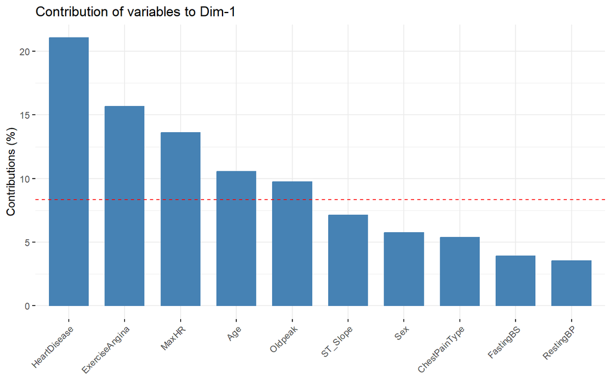

```r
fviz_contrib(res.pca, choice = "var", axes = 1, top = 10)
```

The red dotted line, on the graph above, indicates the expected average contribution.

Here we plot the 10 first variables which contributes better to axis 2.

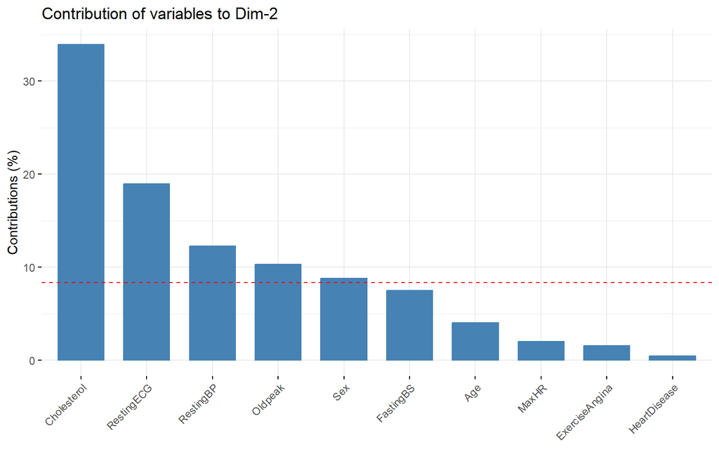

```r
fviz_contrib(res.pca, choice = "var", axes = 2, top = 10)
```

It is possible to use the corrplot() function to highlight the most contributing variables for each dimension.

```r
#library("corrplot")
#corrplot(var$contrib, is.corr=FALSE)
```

Representation of the graph of **individuals**.

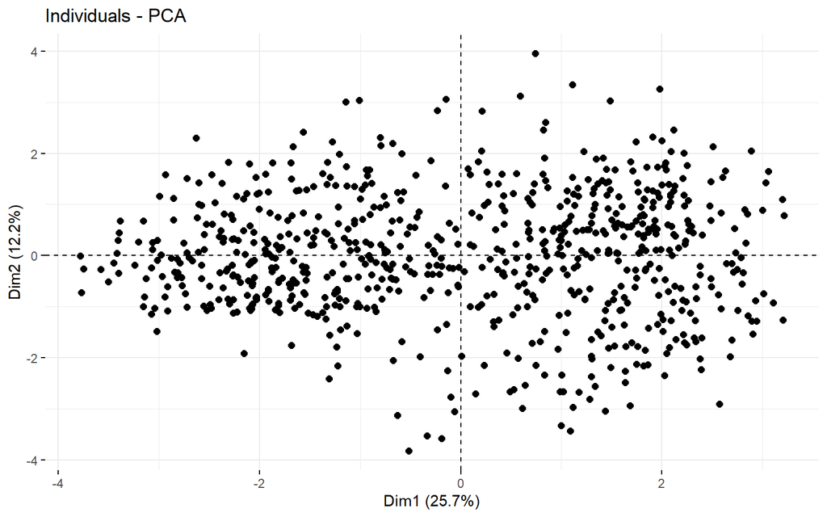

```r
fviz_pca_ind(res.pca, geom="point", pointsize = 2)
```

Here we can see that the individuals are rather concentrated at the level of axis 1 which is normal because axis 1 represents the axis with the most inertia.

Here, we plot the individuals PCA with their quality of representation. More the color of the points(individuals) are purples, the more this individuals have a good quality of representation. A high cos2 indicates a good representation of the variable on the main axes under consideration. In this case, the variable is set near the circumference of the correlation circle.

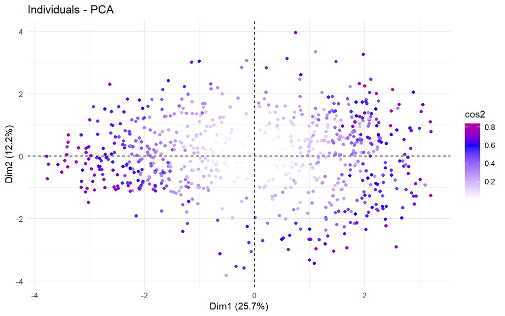

```r
fviz_pca_ind(res.pca, col.ind="cos2", geom = "point") +
      scale_color_gradient2(low="white", mid="blue",
      high="red", midpoint=0.6)+ theme_minimal()
```

Here **2 individuals** projected and very separated on the **first main axis** take **very different** values on many **variables**

**1 individual** close to the center of gravity of the **initial cloud** takes **average** values for many **variables**.

We can visualize the cos2 of variables on all dimensions using the corrplot package.

```r
#library("corrplot")
#corrplot(var$cos2, is.corr=FALSE)
```

# Method that calculates the prediction

```r
calc_acc=function(predicted,actual)
{
  mean(predicted==actual)
}
```

To write on the .csv to put it on kaggle.

```r
csv_write = function(x)
{
  to_be_submitted = data.frame(id=rownames(test_set), HeartDisease = x)

  write.csv(to_be_submitted , file = "11_TAUCH_ASSADI.csv", row.names = F)
}
```

# heat map to see correlated variables

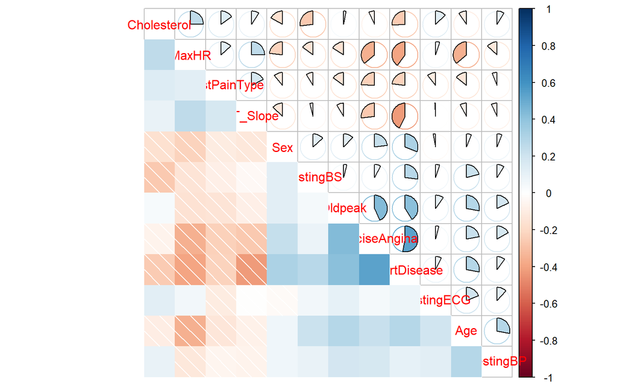

```r
library(corrplot)
corrs <- round(cor(training),2)
corrplot.mixed(corrs,lower = 'shade', upper = 'pie', order = 'hclust')
```

Thanks to our **heat map**, we notice that **HeartDisease** is strongly correlated with **ExerciseAngina**, **Oldpeak**, **ST_Slope**, **MaxHR**, **Sex* *, **FastingBS** and **Cholesterol**.

#1 Multiple Logistic Regression Model

Multiple logistic regression for all **variables**.

```r
model1 <- glm(HeartDisease ~., family = binomial, data = training)
summary(model1)
```

```
##
## Call:
## glm(formula = HeartDisease ~ ., family = binomial, data = training)
##
## Deviance Residuals:
##     Min       1Q   Median       3Q      Max
## -2.9233  -0.4932   0.1737   0.4975   2.6284
##
## Coefficients:
##                Estimate Std. Error z value Pr(>|z|)
## (Intercept)     0.42282    0.12823   3.297 0.000976 ***
## Age             0.09297    0.14622   0.636 0.524869
## Sex             0.44735    0.12633   3.541 0.000398 ***
## ChestPainType  -0.02277    0.12998  -0.175 0.860938
## RestingBP      -0.17137    0.13525  -1.267 0.205145
## Cholesterol    -0.52877    0.14489  -3.649 0.000263 ***
## FastingBS       0.55475    0.13344   4.157 3.22e-05 ***
## RestingECG      0.20209    0.12507   1.616 0.106125
## MaxHR          -0.34379    0.14253  -2.412 0.015866 *
## ExerciseAngina  0.83776    0.14170   5.912 3.38e-09 ***
## Oldpeak         0.81052    0.14531   5.578 2.44e-08 ***
## ST_Slope       -0.90686    0.12287  -7.381 1.58e-13 ***
## ---
## Signif. codes:  0 '***' 0.001 '**' 0.01 '*' 0.05 '.' 0.1 ' ' 1
##
## (Dispersion parameter for binomial family taken to be 1)
##
##     Null deviance: 808.59  on 586  degrees of freedom
## Residual deviance: 424.83  on 575  degrees of freedom
## AIC: 448.83
##
## Number of Fisher Scoring iterations: 5
```

Now, we do an **RLM** with the **high significance** variables which are the same as our **Heatmap**.

```r
model2 <- glm(HeartDisease ~ ExerciseAngina + Oldpeak + ST_Slope + MaxHR + Sex + FastingBS + Cholesterol ,family = binomial, data = training)
summary(model2)
```

```
##
## Call:
## glm(formula = HeartDisease ~ ExerciseAngina + Oldpeak + ST_Slope +
##     MaxHR + Sex + FastingBS + Cholesterol, family = binomial,
##     data = training)
##
## Deviance Residuals:
##     Min       1Q   Median       3Q      Max
## -2.8521  -0.5149   0.1775   0.4952   2.7639
##
## Coefficients:
##                Estimate Std. Error z value Pr(>|z|)
## (Intercept)      0.4398     0.1277   3.444 0.000572 ***
## ExerciseAngina   0.8255     0.1382   5.971 2.36e-09 ***
## Oldpeak          0.8222     0.1375   5.981 2.22e-09 ***
## ST_Slope        -0.8986     0.1211  -7.419 1.18e-13 ***
## MaxHR           -0.3492     0.1352  -2.582 0.009823 **
## Sex              0.4360     0.1269   3.437 0.000588 ***
## FastingBS        0.5660     0.1317   4.297 1.73e-05 ***
## Cholesterol     -0.5204     0.1407  -3.700 0.000216 ***
## ---
## Signif. codes:  0 '***' 0.001 '**' 0.01 '*' 0.05 '.' 0.1 ' ' 1
##
## (Dispersion parameter for binomial family taken to be 1)
##
##     Null deviance: 808.59  on 586  degrees of freedom
## Residual deviance: 429.54  on 579  degrees of freedom
## AIC: 445.54
##
## Number of Fisher Scoring iterations: 5
```

We use the **Binomial** family because we have only **2** possible output either **1** or **0**. I compare their AIC and take the best model therefore **AIC** the smallest.

```r
prediction1 <- predict(model1, testing, type = "response")
prediction2 <- predict(model2, testing, type = "response")

prediction3 <- predict(model2, test_set, type = "response")
#ici d'abors on a mis teststing a la place de test_set pour voir l'accuracy.
# On observe que la moyenne est meilleur donc je l'ai implementé dans test_set


predictionfinal1 <- ifelse(prediction1 > 0.5, 1,0)
predictionfinal2 <- ifelse(prediction2 > 0.5, 1,0)

predictionfinal3 <- ifelse(prediction3 > 0.5, 1,0)
# puis ecrit dans une csv que j'ai soumis (la methode sera tt en bas) car la RLM donne au max 84% pas ouf (j'envoie predictionfinal2 car c'est un fichier de 0 et de 1)

#predictionfinal1
#predictionfinal2


calc_acc(predictionfinal1, testing$HeartDisease)
```

```
## [1] 0.829932
```

```r
calc_acc(predictionfinal2, testing$HeartDisease)
```

```
## [1] 0.8639456
```

```r
csv_write(predictionfinal3) # On écrit le fichier dans un csv
```

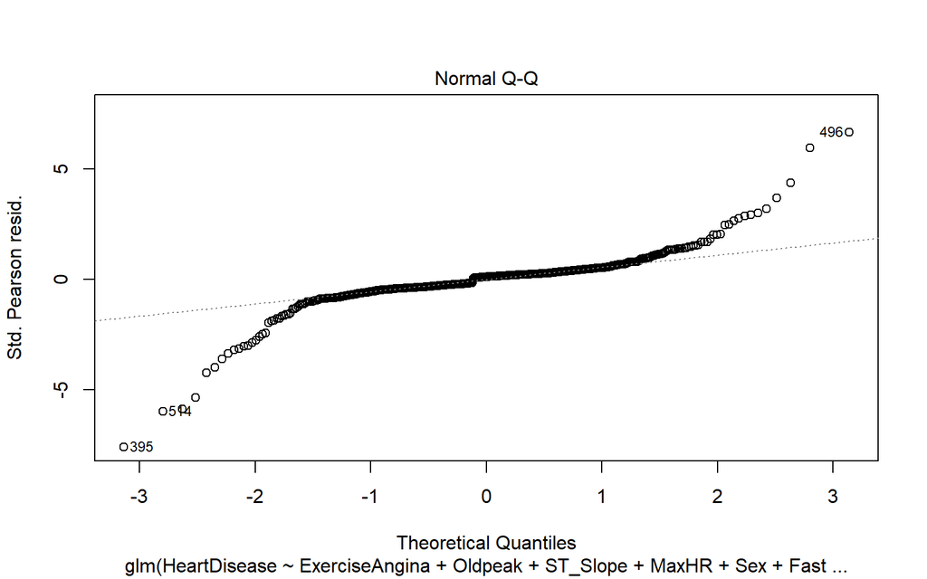

```r
plot(model2,2)
```

# 2 Method Bagging

Now, we are going to test the **Random Forest**. In addition to have the **mtry = nbr variable - 1**

```r
library(randomForest)
bagging <- randomForest(HeartDisease ~ ., training, mtry = 11, importance = TRUE, ntrees = 500)
bagging
```

```
##
## Call:
##  randomForest(formula = HeartDisease ~ ., data = training, mtry = 11,      importance = TRUE, ntrees = 500)
##                Type of random forest: regression
##                      Number of trees: 500
## No. of variables tried at each split: 11
##
##           Mean of squared residuals: 0.1143879
##                     % Var explained: 53.84
```

```r
bagging_pred = predict(bagging,testing,type="class")

calc_acc(bagging_pred,testing$HeartDisease)
```

```
## [1] 0
```

We do not find a very significant model so we move on.

# 3 model Random Forest

Here to get the **mtry = sqrt(nbr variable - 1)**

```r
modelerf=randomForest(HeartDisease~ .,data=training,mtry=3,importance= TRUE,ntrees=500)

modelerf_pred=predict(modelerf,testing,type="class")

calc_acc(modelerf_pred,testing$HeartDisease)
```

```
## [1] 0
```

De même, on trouve moyenne nul je prend meme pas la peine de le transoformer en 0 1 et a submit.

# 4 Method of boosting gbm

```r
library(gbm)
HD_boost=gbm(HeartDisease ~.,data=training,distribution="bernoulli",n.trees=800,interaction.depth=4,shrinkage=0.01)

HD_boost_pred =  predict(HD_boost,testing,type="response")
```

```
## Using 800 trees...
```

```r
HD_boost_pred2 =  predict(HD_boost,test_set,type="response")
```

```
## Using 800 trees...
```

```r
HD_boost_pred01 = ifelse(HD_boost_pred >= 0.5, 1,0)
HD_boost_pred02 = ifelse(HD_boost_pred2 >= 0.5, 1,0)

acc_boost = calc_acc(HD_boost_pred01, testing$HeartDisease)
acc_boost
```

```
## [1] 0.8571429
```

```r
csv_write(HD_boost_pred02)
```

# Matrix of confusion

```r
confusion_matrix <- table(testing$HeartDisease, HD_boost_pred01)
confusion_matrix
```

```
##    HD_boost_pred01
##      0  1
##   0 54 13
##   1  8 72
```

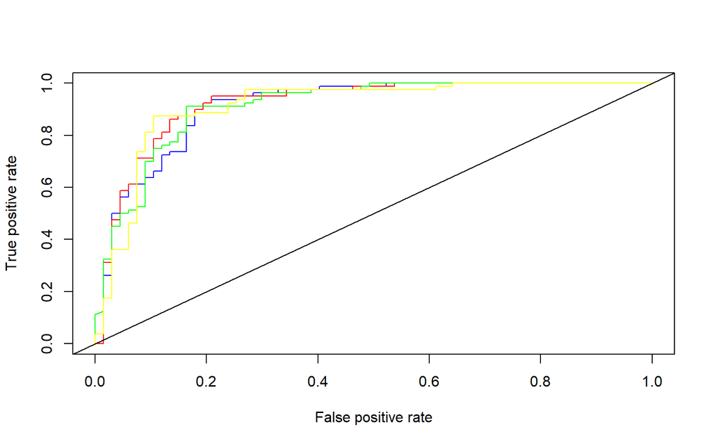

```r
library(ROCR)
result1 <- prediction(HD_boost_pred, testing$HeartDisease)
Auc1 <- performance(result1, "auc")

result2 <- prediction(modelerf_pred, testing$HeartDisease)
Auc2 <- performance(result2, "auc")

result3 <- prediction(bagging_pred, testing$HeartDisease)
Auc3 <- performance(result3, "auc")

result4 <- prediction(prediction2, testing$HeartDisease)
Auc4 <- performance(result4, "auc")

plot(performance(result1, "tpr", "fpr"), col = "blue")
plot(performance(result2, "tpr", "fpr"), col = "red", add = TRUE)
plot(performance(result3, "tpr", "fpr"), col = "green", add = TRUE)
plot(performance(result4, "tpr", "fpr"), col = "yellow", add = TRUE)
abline(0, 1, lty = 1)
```

Here in red the **Random Forest**, in green the **bagging**, yellow the **RLM** and finally in blue the **boosting**.

# Summarize of all models

```r
HD_acc = data.frame(
  Modele = c("Logistic Regression", "Bagging",  "Random Forest",  "Boosting"),
  Accuracy = c(calc_acc(predictionfinal2, testing$HeartDisease), calc_acc(bagging_pred,testing$HeartDisease), calc_acc(modelerf_pred,testing$HeartDisease), acc_boost)
)
HD_acc
```

```
##                Modele  Accuracy
## 1 Logistic Regression 0.8639456
## 2             Bagging 0.0000000
## 3       Random Forest 0.0000000
## 4            Boosting 0.8571429
```